# cover_story_test

2025-08-19

## A check to see if cover story affected answering

There are three cover stories. In slightly condensed form, they are:

> The situation is … a person walking down a street full of cafes, looking for a place to eat. They have already decided what they want to eat: a main dish, a dessert, or both. They read the menus, and decide whether to enter and eat something. If the food is on the menu and they want to eat it, they will enter the cafe. [10%] of the cafes have main dishes and [80%] have desserts. The person wants to eat a main dish [70%] of the time and wants to eat a dessert [50%] of the time. The person enters the cafe to order if [either one / both ] of the main dish or dessert is on the menu and the person wants to eat what is on the menu.

> The situation is … an afternoon university seminar class. The class is compulsory, but two particular students only sometimes attend. These two students are intelligent, passionate, articulate and well-read. However, even when they attend, they are only in the mood to talk if they have had a good morning! (Their morning and hence their mood does not affect how likely they are to turn up; a bad morning just makes them quiet.) But if they attend and had a good morning, there will always be a good discussion. The first student attends [10%] of the time and the second student attends [80%] of the time. The first student has a good morning [70%] of the time, and the second student has a good morning [50%] of the time. A good discussion always happens when [either/both] student attends and had a good morning.

> The situation is a work meeting, where a company is trying to sell a product to a client. The presenter introduces some features in a talk, and then opens files to demonstrate. However, the laptop files are sometimes randomly corrupted and fail to open! The presenter does not know in advance which files are corrupted. The product has Feature A and Feature B, and the client will always accept the product if they see a working demonstration of [either/both] feature[/s]. The company presents Feature A [10%] of the time and Feature B [80%] of the time. The underlying laptop files for Feature A are sometimes corrupted: they only work [70%] of the time, whether the feature is presented or not. The underlying laptop files for Feature B are sometimes corrupted: they only work [50%] of the time, whether the feature is presented or not.

### STATISTICAL TEST

I split the data up by pgroup, and by trialtype, then inside each ran a Fisher’s exact test on the discrete numbers of choices of each variable, compared across the three cover stories.

#### Results of the Fisher’s exact test:

```r
  pvals <- sapply(results_list, function(x) if (is.list(x)) x$p.value else NA)
print(pvals)
```

```
##       1_c1       1_c2       1_c3       1_c4       1_c5       1_d1       1_d2
## 0.34546545 0.24497550 0.01099890 0.71202880 0.91950805 0.03109689 0.31806819
##       1_d3       1_d4       1_d5       1_d6       1_d7       2_c1       2_c2
## 0.61053895 0.09409059 0.18068193 0.44205579 0.01739826 0.08289171 0.31626837
##       2_c3       2_c4       2_c5       2_d1       2_d2       2_d3       2_d4
## 0.27647235 0.26547345 0.02069793 0.66103390 0.40255974 0.81651835 0.07549245
##       2_d5       2_d6       2_d7       3_c1       3_c2       3_c3       3_c4
## 0.93930607 0.41285871 0.00109989 0.47455254 0.49875012 0.03519648 0.03979602
##       3_c5       3_d1       3_d2       3_d3       3_d4       3_d5       3_d6
## 0.13598640 0.68253175 0.00949905 0.75072493 0.82391761 0.15428457 0.36636336
##       3_d7
## 0.00019998
```

In fact, the numbers are not comparable: because of the way the probabilities and cover stories were sampled rather than force divided and matched, perhaps there are more in some condition by a quirk of sampling?

So, use proportions instead of counts.

Normalise and plot the proportions:

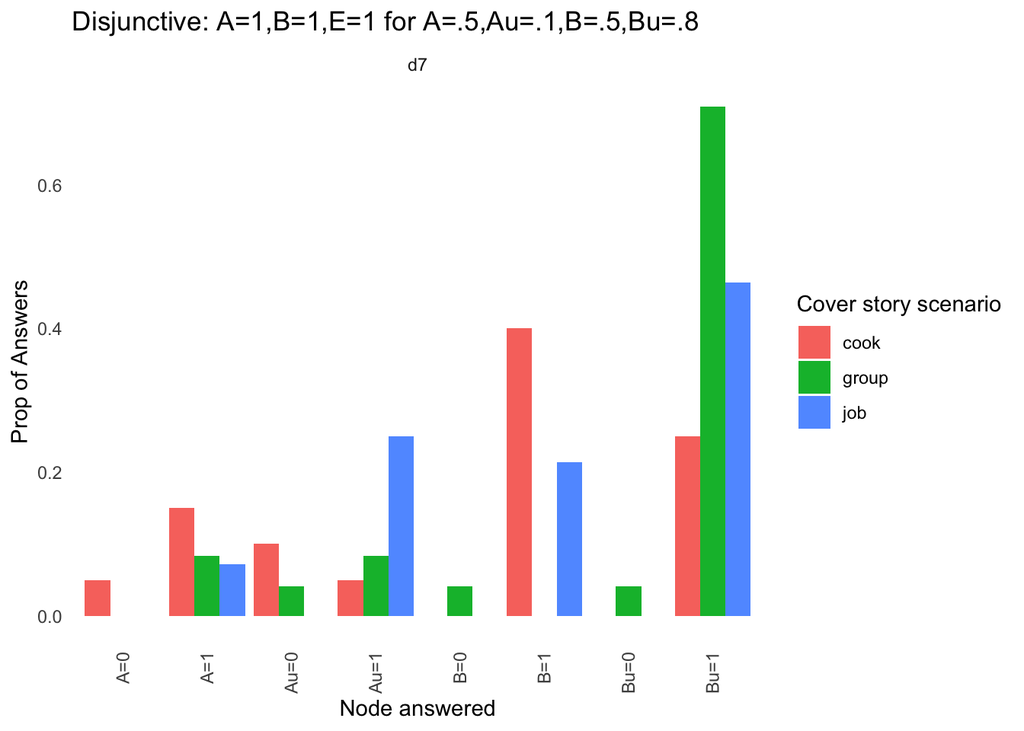

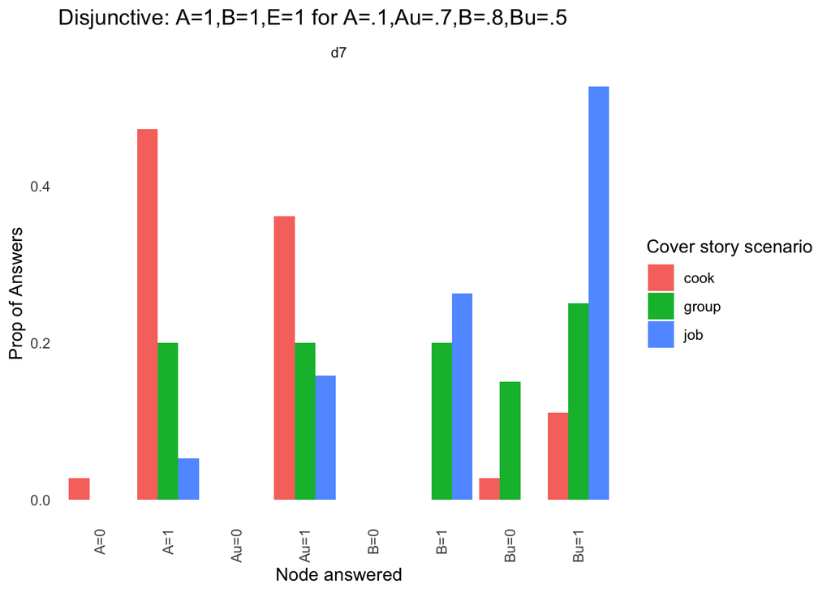

So in general… not sure what to do. It seems for this important trialtype (D111) the cover stories give rise to different participant behaviours. Especially the cafe one (here called ‘cook’ for legacy reasons - that didn’t affect what participants saw) and the job one are dissociated.

I guess the next thing is to compare with model predictions? but I should find the reason first. How should I report it, if people react differently to different stories?